```python
from IPython.display import HTML
HTML('''<script>
code_show=true;
function code_toggle() {
 if (code_show){
 $('div.input').hide();
 } else {
 $('div.input').show();
 }
 code_show = !code_show
}
$( document ).ready(code_toggle);
</script>
 <form action="javascript:code_toggle()"><input type="submit" value="Click here to toggle on/off the full code."></form>''')
```

# Building Probability of Default Using Fannie Mae Data

### **Description:**

Building probabiliyt of default model using Fannie Mae Single Family Fixed Rate Mortgage Datasets. Fannie Mae provides loan acquisition and performance data on a portion of its single-family mortgage loans to promote better understanding of the credit performance of Fannie Mae mortgage loans. The population includes two datasets.

The datasets consist of two tables - (i) Acquisition Data & (ii) Performance Data. Every quarter, the repository is updated to add another quarter of acquisitions and performances.

*Reference Link:* - [Fannie Mae](https://loanperformancedata.fanniemae.com/lppub/index.html#Portfolio)

### **Variable Definition**

Definition of few key metrics used in model development

- Loan_IDENTIFIER: Unique key for borrowers
- Default Flag: Whether a loan defaults in 12 months after acquired by Fannie Mae. 0 if the loan is performing, 1 if the laon defaults.
- Loan to Value(LTV) - Reflects the loan-to-value ratio of the loan amount secured by a mortgaged property on the origination date of the underlying mortgage loa
- Combined Loan to Value(LTV) - Reflects the loan-to-value ratio inclusive of all loans secured by a mortgaged property on the origination date of the underlying mortgage loan.
- Debt to Income Ratio - Ratio of borrower’s total monthly obligations (including housing expense) by his or her stable monthly income
- Loan Purpose: Indicator denoting type of mortgage loan
  - P - Purchase Mortgage
  - C - Cash Out Mortgage
  - R - No Cash Out Mortgage
  - U - Refinance Mortgage Purpose may be the purchase of a new property or refinance of an existing lien (with cash out or with no cash out).

### **Event Definition - Default**

Borrowers are said to be non perfrofming or defaulting the loan when they have missed the monthly paymnets for 90 days(3 Months). But since majority of Fannie Mae acquired mortgage are prime loans, the number of defaults using conventional definition is too low(< 0.05%).

Hence, for this case study, the default is taken as loan that failed to meet the monthly payment obligations for two months or more.

### **Key Challenges**

Main obstacles while developing the default model were:

- Imbalanced Dataset
- Absence of key informations

```python
import sys
sys.path.append('C:\\Users\\SDwivedi\\AppData\\Local\\Programs\\Python\\Python37\\Lib\\site-packages')
print(sys.path)

import warnings
warnings.filterwarnings('ignore')

import pandas as pd
import numpy as np

import matplotlib.pyplot as plt
plt.rc("font", size=14)

import seaborn as sns
sns.set(style="white")
sns.set(style="whitegrid", color_codes=True)

import itertools
from sklearn.metrics import confusion_matrix, precision_recall_curve, auc, roc_auc_score, roc_curve, recall_score, classification_report
from sklearn.metrics import accuracy_score

from sklearn.model_selection import GridSearchCV
from sklearn.linear_model import LogisticRegression



from sklearn.preprocessing import LabelEncoder

from sklearn import preprocessing

from sklearn.cross_validation import train_test_split

import _pickle as pickle
import requests
import json

import vertica_python as vc
from imblearn import under_sampling, over_sampling
from imblearn.over_sampling import SMOTE
```

#### We have the FM data in Vertica, a Column based DMBS, supporting quick execution of queries.

```python
conn_info = {'host': '13.232.211.49',
             'port': 5433,
             'user': 'dbadmin',
             'password': 'P0tom@c@207',
             'database': 'POTOMACDB',
             'read_timeout': 60000
            }
connection = vc.connect(**conn_info)

cur = connection.cursor()
```

```python
cur = connection.cursor()
cur.execute("select * from fannie_mae.training_data")
print('')
```

```python
result = pd.DataFrame(cur.fetchall())
colnames = pd.DataFrame(cur.description)
colnames2 = list(colnames.iloc[:,0].T)
result.columns = colnames2
# result.head()
```

```python
indata = result.copy()

indata.drop(["obs_rank","property_state","current_interest_rate","origination_date",
           "monthly_reporting_period","maturity_date","current_loan_delinquency_status","vint_orgn","obs_rank","servicer_name",
           "zip","qtr_orgn","month_defaulting","metropolitan_statistical_area","seller_name","mortgage_insurance_percentage"],
            axis=1, inplace=True)
```

```python
int_cols = ["original_interest_rate","original_loan_term","original_unpaid_principal_balance",
            "original_loan_to_value","original_combined_loan_to_value","number_of_borrowers","debt_to_income_ratio",
            "borrower_credit_score","number_of_units","coborrower_credit_score",
            "default_flag","loan_id_perf"]

char_cols = ["origination_channel","first_time_home_buyer_indicator","loan_purpose","property_type","occupancy_status",
             "relocation_mortgage_indicator",
             "mortgage_insurance_type"]

# print('int_cols, char_cols, date_cols are as: \n', len(int_cols), len(char_cols))
```

```python
indata[int_cols]  = indata[int_cols].fillna(np.nan)
indata[char_cols] = indata[char_cols].fillna('')
```

```python
for i in int_cols:
    indata[i] = indata[i].astype(np.float64)
```

```python
# result.dtypes.value_counts()
# indata.dtypes.value_counts()
```

```python
# result.to_csv('C:/Users/SDwivedi/Fannie Mae/Data from Vertica/indata.csv', sep='\t')
```

#### Default borrowers in sample data:

```
The distribution of Target Variable -

default_flag  # Loans
         0.0   400000
         1.0     1484

Borrowers who defaulted are tagged as 1, others as 0.

This is a highly imbalanced dataset with minority class as :0.371 % of total data points.

Training data shape:  (401484, 19)
```

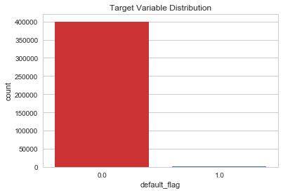

```python
d1 = pd.DataFrame(indata.groupby(['default_flag']).size().to_frame('# Loans').reset_index())
NDeflt = d1.iloc[0,1]
Deflt  = d1.iloc[1,1]

print('The distribution of Target Variable -\n')
print(indata.groupby(['default_flag']).size().to_frame('# Loans').reset_index().to_string(index=False))
print('\nBorrowers who defaulted are tagged as 1, others as 0.\n')
print('This is a highly imbalanced dataset with minority class as :' + str(round(100*Deflt/NDeflt,4)) + ' % of total data points.')
print('\nTraining data shape: ', indata.shape)

ax = sns.countplot(x="default_flag", data=indata, palette = "Set1").set_title('Target Variable Distribution')
plt.show()
```

```python
#### -- Get Classes / Levels of a categorical Variable -- ####
def getclasses(df):
    i = 0
    F = pd.DataFrame()
    for c in df.select_dtypes(include = ['object']).columns:
        if c != 'mortgage_insurance_type':
            t_i = pd.DataFrame(df[c].unique()).rename(columns={0: c}).sort_values(by=c).reset_index()
        else:
            t_i = pd.DataFrame(df[c].unique()).rename(columns={0: c}).reset_index()

        F = pd.concat([F, t_i.iloc[:,1]], axis=1)
        i += 1

    F = F.replace(np.nan, '', regex=True).T

    NClass = []
    for r in range(0,len(F)):
        i = 0
        robs = F.iloc[r,:]
        for c in robs:
            if (c == ""):
                continue
            else:
                i +=1
        NClass.append(i)

    df2 = F
    df2['NClass'] = NClass

    cols = df2.columns.tolist()
    cols = cols[-1:] + cols[:-1]
    df2 = df2[cols]
    return df2.sort_values('NClass', ascending = False)

#### -- Fields with Missing Values -- ####
def missing_values_table(df):
        mis_val = df.isnull().sum()
        mis_val_percent = 100 * df.isnull().sum() / len(df)
        mis_val_table = pd.concat([mis_val, mis_val_percent], axis=1)
        mis_val_table_ren_columns = mis_val_table.rename(
        columns = {0 : 'Missing Values', 1 : '% of Total Values'})

        mis_val_table_ren_columns = mis_val_table_ren_columns[
            mis_val_table_ren_columns.iloc[:,0] != 0].sort_values('% of Total Values', ascending=False).round(1)

        print ("Selected dataframe has " + str(df.shape[1]) + " columns.\n"
            "There are " + str(mis_val_table_ren_columns.shape[0]) +
              " columns that have missing values.")

        # Return the dataframe with missing information
        return mis_val_table_ren_columns
```

#### Categorical variables & corresponding classes:

```python
getclasses(indata)
```

|  | NClass | 0 | 1 | 2 | 3 | 4 |
| --- | --- | --- | --- | --- | --- | --- |
| property_type | 5 | CO | CP | MH | PU | SF |
| origination_channel | 3 | B | C | R |  |  |
| loan_purpose | 3 | C | P | R |  |  |
| occupancy_status | 3 | I | P | S |  |  |
| first_time_home_buyer_indicator | 2 | N | Y |  |  |  |
| mortgage_insurance_type | 2 |  | 1 | 2 |  |  |
| relocation_mortgage_indicator | 2 | N | Y |  |  |  |

#### Parameters with Missing Values:

```python
missing_values_table(indata)
```

```
Selected dataframe has 19 columns.
There are 3 columns that have missing values.
```

|  | Missing Values | % of Total Values |
| --- | --- | --- |
| coborrower_credit_score | 173756 | 43.3 |
| borrower_credit_score | 177 | 0.0 |
| debt_to_income_ratio | 44 | 0.0 |

A normalized credit score is created by taking the mean of borrower_credit_score & coborrower_credit_score are for loans with two or more borrowers. Each of latter two columns are then removed from the final model development.

#### Distribution of Loan Amount sanctioned and the purpose of Loan & corresponding classes:

- P : Purchase Mortgage
- C : Cash Out Mortgage
- R : No Cash Out Mortgage
- U : Refinance Mortgage

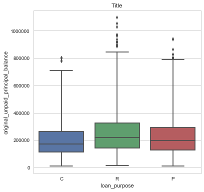

```python
fig, ax =plt.subplots(figsize=(6,6))
sns.boxplot(x='loan_purpose', y='original_unpaid_principal_balance', data=indata, whis = 3).set_title('Title')
plt.show()
```

As can be seen from the above box plot, the average loan amount sanctioned is fairly same accross the three purposes.

#### Effect of Credit Score, Debt to Income and LTV on Default

The following plots clearly shows the impact of Credit Score, Debt to Income and LTV on Default. Borrower's tendency to default on loan is more for borrowers with lower credit score and higher LTV/DTI/CLTV ratio.

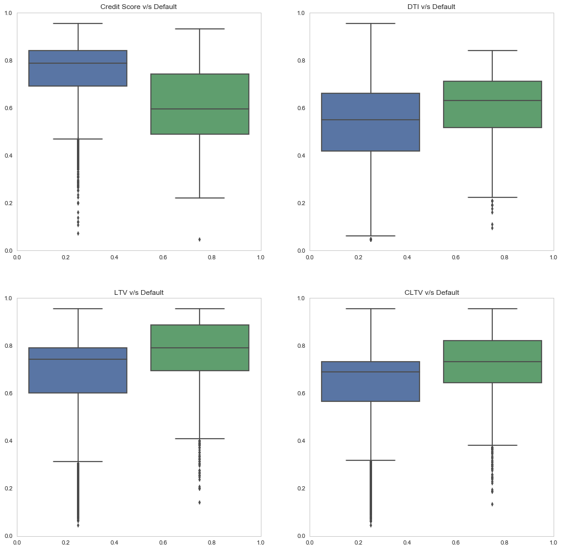

```python
fig, ax =plt.subplots(2,2,figsize=(16,16))
ax = fig.add_subplot(2,2,1)
sns.boxplot(x='default_flag', y='borrower_credit_score', data=indata).set_title('Credit Score v/s Default')
ax.set_ylabel('')
ax.set_xlabel('')
ax.set_yticks(())
ax.set_xticks(())

ax = fig.add_subplot(2,2,2)
sns.boxplot(x='default_flag', y='debt_to_income_ratio', data=indata).set_title('DTI v/s Default')
ax.set_ylabel('')
ax.set_xlabel('')
ax.set_yticks(())
ax.set_xticks(())

ax = fig.add_subplot(2,2,3)
sns.boxplot(x='default_flag', y='original_loan_to_value', data=indata).set_title('LTV v/s Default')
ax.set_ylabel('')
ax.set_xlabel('')
ax.set_yticks(())
ax.set_xticks(())

ax = fig.add_subplot(2,2,4)
sns.boxplot(x='default_flag', y='original_combined_loan_to_value', data=indata).set_title('CLTV v/s Default')
ax.set_ylabel('')
ax.set_xlabel('')
ax.set_yticks(())
ax.set_xticks(())

plt.show()
```

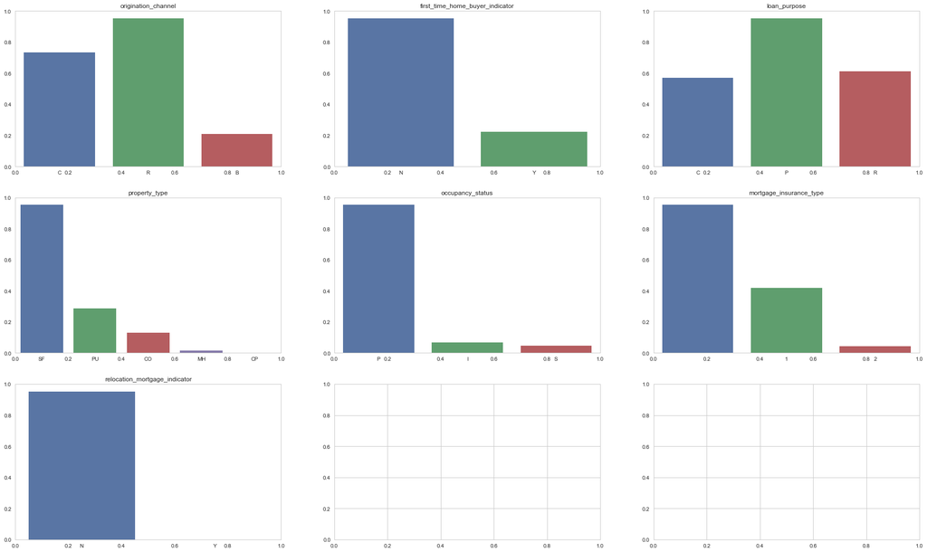

```python
fig, ax =plt.subplots(3,3, figsize=(30,18))

j = 1
for col in indata:
    if indata[col].dtype == 'object':
        ax = fig.add_subplot(3,3,j)
        sns.countplot(x=col, data=indata[indata.default_flag == 1]).set_title(col)
        ax.set_ylabel('')
        ax.set_xlabel('')
        ax.set_yticks(())

        j = j + 1
fig.show()
plt.show()
```

```python
Retain_Features = ['loan_id_perf','origination_channel','original_interest_rate','property_type','number_of_borrowers',
                   'original_combined_loan_to_value','debt_to_income_ratio','first_time_home_buyer_indicator',
                   'number_of_units','mortgage_insurance_type', 'loan_purpose','coborrower_credit_score',
                   'relocation_mortgage_indicator','default_flag','original_loan_term','original_loan_to_value',
                   'borrower_credit_score','occupancy_status','original_unpaid_principal_balance']

indata2 = pd.DataFrame()

for c in Retain_Features:
    indata2[c] = indata[c]

indata2.shape
```

```
(401484, 19)
```

### Converting Categorical to numerical Dummy Variables:

```python
getclasses(indata2)
```

|  | NClass | 0 | 1 | 2 | 3 | 4 |
| --- | --- | --- | --- | --- | --- | --- |
| property_type | 5 | CO | CP | MH | PU | SF |
| origination_channel | 3 | B | C | R |  |  |
| loan_purpose | 3 | C | P | R |  |  |
| occupancy_status | 3 | I | P | S |  |  |
| first_time_home_buyer_indicator | 2 | N | Y |  |  |  |
| mortgage_insurance_type | 2 |  | 1 | 2 |  |  |
| relocation_mortgage_indicator | 2 | N | Y |  |  |  |

```python
missing_values_table(indata2)
```

```
Selected dataframe has 19 columns.
There are 3 columns that have missing values.
```

|  | Missing Values | % of Total Values |
| --- | --- | --- |
| coborrower_credit_score | 173756 | 43.3 |
| borrower_credit_score | 177 | 0.0 |
| debt_to_income_ratio | 44 | 0.0 |

```python
# indata2.groupby(['number_of_borrowers', 'coborrower_credit_score']).size().to_frame('size').reset_index()
# indata2.coborrower_credit_score.value_counts(dropna=False)        #NaN - 193,816
indata2.number_of_borrowers.value_counts(dropna=False).reset_index().sort_values('index')
# Loans having 1 Borrower for 193,501
```

|  | index | number_of_borrowers |
| --- | --- | --- |
| 1 | 1.0 | 173525 |
| 0 | 2.0 | 226667 |
| 2 | 3.0 | 981 |
| 3 | 4.0 | 301 |
| 4 | 5.0 | 6 |
| 5 | 6.0 | 4 |

```python
np.isnan(indata.coborrower_credit_score).value_counts()
```

```
False    227728
True     173756
Name: coborrower_credit_score, dtype: int64
```

```python
indata2['FICO'] = np.where(indata2.number_of_borrowers > 1,
                          (indata2.coborrower_credit_score + indata2.borrower_credit_score)/2,
                          indata2.borrower_credit_score)
```

```python
indata2['FICO'].corr(indata2['borrower_credit_score'])
```

```
0.9587478526681286
```

```python
del indata2['borrower_credit_score']
del indata2['coborrower_credit_score']
```

```python
indata2.dropna(how='any', inplace = True)
```

```python
indata2.shape
```

```
(401049, 18)
```

```python
indata2[indata2.default_flag == 1].shape
```

```
(1476, 18)
```

```python
missing_values_table(indata2)
```

```
Selected dataframe has 18 columns.
There are 0 columns that have missing values.
```

|  | Missing Values | % of Total Values |
| --- | --- | --- |

```python
getclasses(indata2)
```

|  | NClass | 0 | 1 | 2 | 3 | 4 |
| --- | --- | --- | --- | --- | --- | --- |
| property_type | 5 | CO | CP | MH | PU | SF |
| origination_channel | 3 | B | C | R |  |  |
| loan_purpose | 3 | C | P | R |  |  |
| occupancy_status | 3 | I | P | S |  |  |
| first_time_home_buyer_indicator | 2 | N | Y |  |  |  |
| mortgage_insurance_type | 2 |  | 1 | 2 |  |  |
| relocation_mortgage_indicator | 2 | N | Y |  |  |  |

```python
le = LabelEncoder()
le_count = 0

# Iterate through the columns
for col in indata2:
    if indata2[col].dtype == 'object':
        if len(list(indata2[col].unique())) <= 2:
            le.fit(indata2[col])
            indata2[col] = le.transform(indata2[col])
            le_count += 1

print('%d columns were label encoded.' % le_count)
```

```
2 columns were label encoded.
```

```python
indata2 = pd.get_dummies(indata2)
print('Training Features shape: ', indata2.shape)
```

```
Training Features shape:  (401049, 30)
```

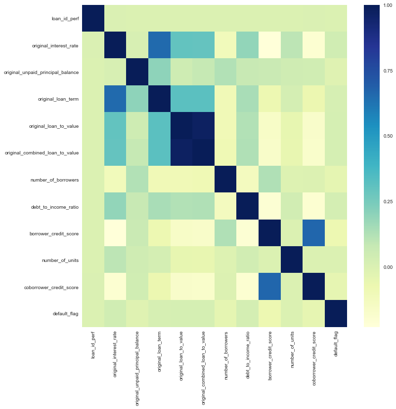

```python
fig, ax =plt.subplots(figsize=(12,12))
sns.heatmap(indata.corr(), cmap="YlGnBu")
plt.show()

# -- Might have to look to drop Highly Correlated Variables
```

```python
indata3 = indata2.copy()

indata3 = indata3.set_index('loan_id_perf')

list1 = (indata3.columns)
features = ','.join(list1)

y = indata3.default_flag
X = indata3.drop(['default_flag'], axis=1)

X_train, X_test, y_train, y_test = train_test_split(X, y, test_size=0.30, random_state=0)
print(X_train.shape, X_test.shape, y_train.shape, y_test.shape)
```

```
(280734, 28) (120315, 28) (280734,) (120315,)
```

```python
features
```

[output not shown]

```python
# finalparams = indata3.columns.shape - 1
```